# Reproducible Research: Peer Assessment 1

## Loading and preprocessing the data

```r
unzip('activity.zip')
activity <- read.csv('activity.csv', sep=",",quote="\"", dec=".", fill=TRUE)
```

## What is mean total number of steps taken per day?

- Remove incomplete observations

```r
activity_clear <- activity[complete.cases(activity),]
activity_clear$date <- as.Date(activity_clear$date)
```

- load *plyr* library

```r
library(plyr)
```

- create new data frame with sum of steps taken each day

```r
StepsDaily <- ddply(activity_clear,~date,summarise,sum=sum(steps))
```

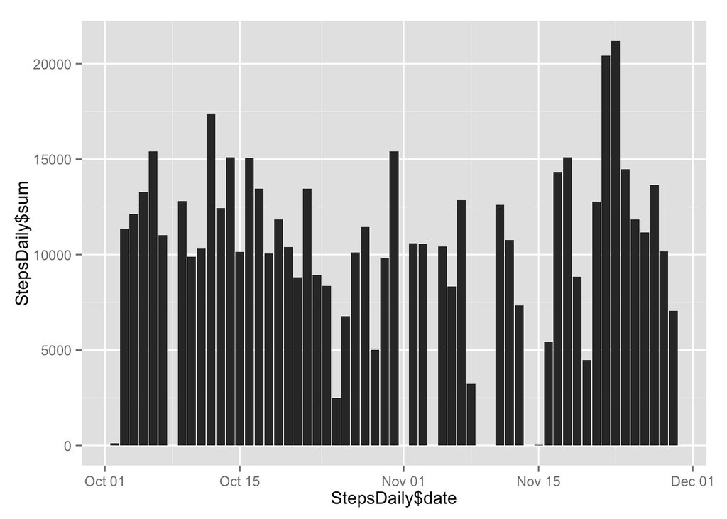

```r
library(ggplot2)
print( qplot(StepsDaily$date,StepsDaily$sum, geom='bar', stat='identity') )
```

```r
summary(StepsDaily)
```

```
##       date                 sum
##  Min.   :2012-10-02   Min.   :   41
##  1st Qu.:2012-10-16   1st Qu.: 8841
##  Median :2012-10-29   Median :10765
##  Mean   :2012-10-30   Mean   :10766
##  3rd Qu.:2012-11-16   3rd Qu.:13294
##  Max.   :2012-11-29   Max.   :21194
```

- calulate mean

```r
mean(StepsDaily$sum)
```

```
## [1] 10766.19
```

- calulate median

```r
median(StepsDaily$sum)
```

```
## [1] 10765
```

## What is the average daily activity pattern?

- create necessary data frame

```r
StepsInterval <- ddply(activity_clear,~interval,summarize,mean=mean(steps))
```

- plot a line that show mean number of steps taken at given interval

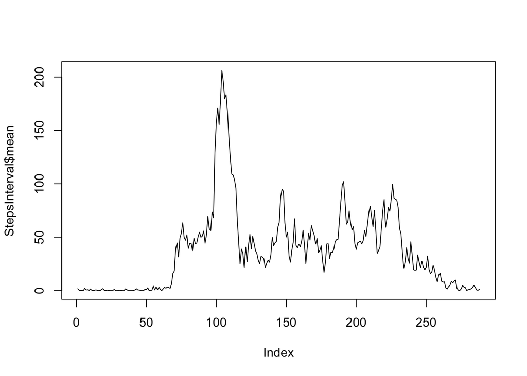

```r
plot(StepsInterval$mean, type="l")
```

```r
StepsInterval[max(StepsInterval$mean),]
```

```
##     interval     mean
## 206     1705 56.30189
```

## Inputing missing values

- identify subset that has missing values

```r
activity_missing <- activity[is.na(activity),]
```

- assign zero to all missing values

```r
activity_missing$steps <- 0
```

- creates a new data frame that merges data from missing subset with average data

```r
activity_missing_completed <- merge(activity_missing,StepsInterval, by.x = "interval", by.y = "interval")
```

- assing a mean to all missing values and drop unnecessary column

```r
activity_missing_completed$steps <- activity_missing_completed$mean
activity_missing_completed$mean <- NULL
```

- binds both complete.cases dataframes

```r
activity_na_imput <- rbind(activity_clear,activity_missing_completed)
```

- creates sums over particular dates (with new data) and plots appropriate chart

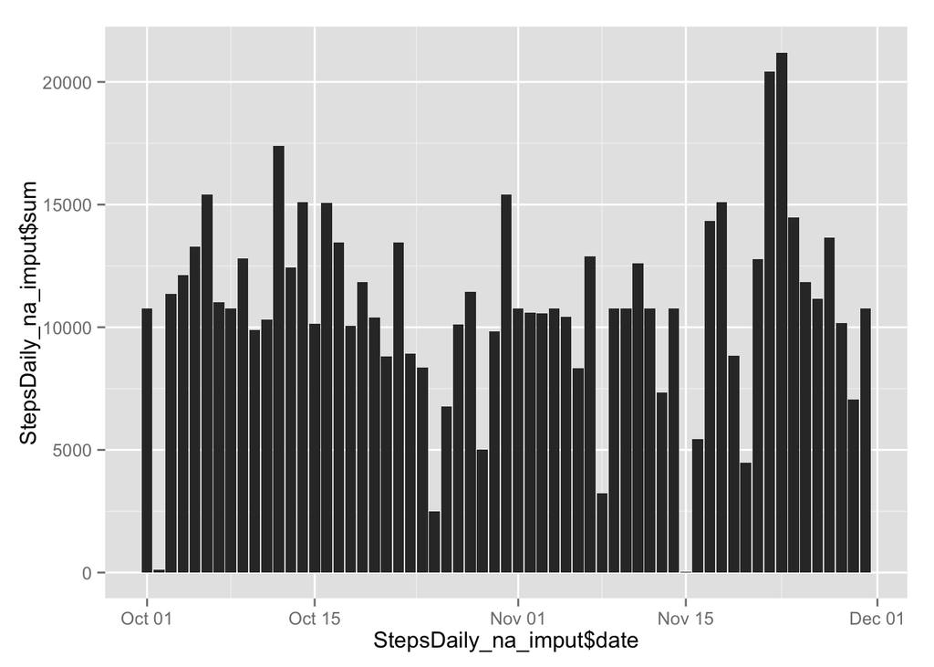

```r
StepsDaily_na_imput <- ddply(activity_na_imput,~date,summarise,sum=sum(steps))
print( qplot(StepsDaily_na_imput$date,StepsDaily_na_imput$sum, geom='bar', stat='identity') )
```

- new mean value

```r
mean(StepsDaily_na_imput$sum)
```

```
## [1] 10766.19
```

- new median value

```r
median(StepsDaily_na_imput$sum)
```

```
## [1] 10766.19
```

## Are there differences in activity patterns between weekdays and weekends?

- adds another column that changes the date into weekday name

```r
activity_na_imput$day <- weekdays(as.Date(activity_na_imput$date))
```

- creates a data frame that converts day name to weekeday or weekend, accordingly

```r
weekend_frame <- data.frame(day=c("Monday","Tuesday", "Wednesday", "Thursday","Friday","Saturday","Sunday"),weekend=c("weekday","weekday","weekday","weekday","weekday","weekend","weekend"))
```

- joins two above frames to distinct beetween “weekend” and “weekday” readings

```r
activity_na_imput <- merge(activity_na_imput,weekend_frame, by.x="day",by.y="day")
```

- creates summary dataframe and plots it in two panels to compare “weekend” and “weekday” readings

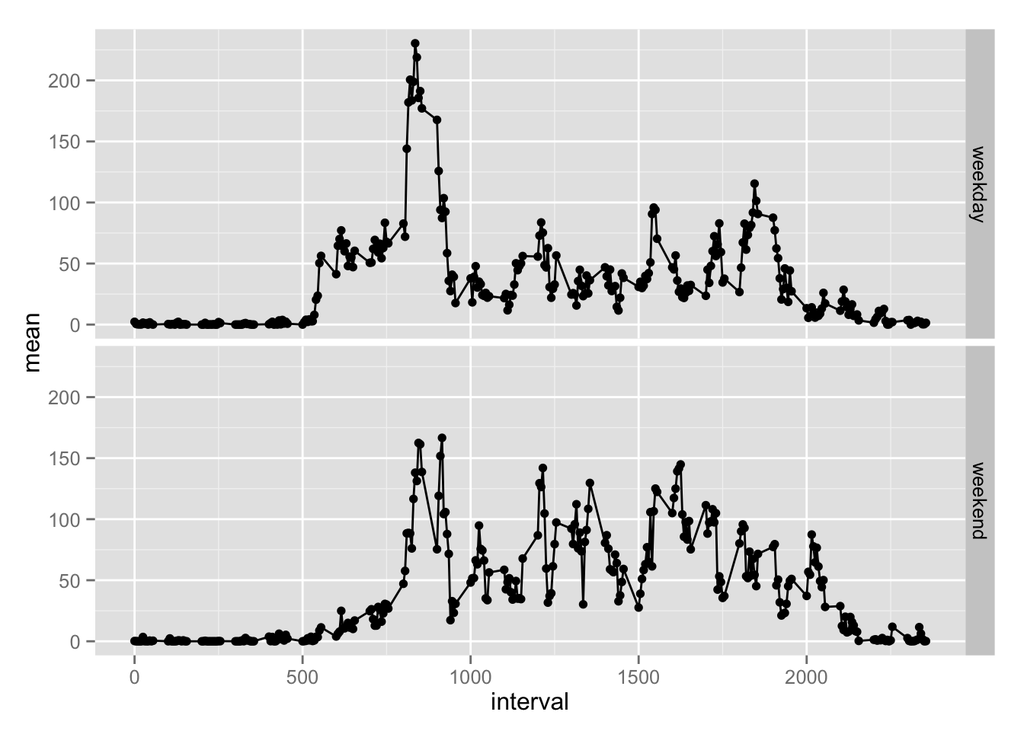

```r
StepsIntervalWeekend <- ddply(activity_na_imput,.(weekend,interval),summarise,mean=mean(steps))
g <- qplot(interval, mean, data = StepsIntervalWeekend)
g <- g + facet_grid(weekend ~.) + geom_line()
g
```